# Lab 9: Introduction to Unsupervised Learning - Clustering 🎯

**Course:** COMPX310 - Machine Learning  
**Worth:** 3%

**Student Name:** Guo Zimo  
**Student ID:** 20233006327  
**Partner Name (if applicable):**  
**Partner ID (if applicable):**

**Note:** This lab is designed to introduce you to clustering BEFORE the theory lecture. Don't worry if some concepts are new - we'll explain everything step by step! 🚀

1. What is Unsupervised Learning?
2. What is Clustering?
3. K-Means Clustering Explained
4. Hierarchical Clustering Explained
5. Understanding the Dataset
6. Exploratory Data Analysis (EDA)
7. Task 1: K-Means Clustering with 2 Features
8. Task 2: Choosing K with the Elbow Method
9. Task 3: K-Means with All Features
10. Task 4: Hierarchical Clustering with 2 Features
11. Task 5: Hierarchical Clustering with All Features
12. Discussion Questions

## 1. What is Unsupervised Learning?

- We have data but **NO labels**
- We don't know the "right answer"
- We want the computer to find **patterns** on its own
- It's like learning **WITHOUT a teacher** - you explore and discover patterns yourself!

### Real-Life Example: Organizing Your Closet 👕👗

Imagine you have a messy closet with 100 pieces of clothing all mixed up:

**Supervised Learning Approach:**

- Someone labels each item: "This is formal", "This is casual", "This is sportswear"
- You learn to put similar items together based on these labels

**Unsupervised Learning Approach:**

- **No one tells you** what categories to use
- You look at the clothes and notice: "Hey, these 10 items are all similar (maybe they're all jeans)"
- You create groups naturally: Group 1 (shirts), Group 2 (pants), Group 3 (shoes)
- You discovered the pattern **on your own**!

### Types of Unsupervised Learning

There are two main types:

1. **Clustering** 🎯 (What we'll learn today!)
   - Group similar items together
   - Example: Group customers by shopping behavior
2. **Association Rules** 📉 (For another day)
   - Link one variable with another
   - Example: if a person buy a bread he might be interested to buy a milk

**Today we focus on CLUSTERING!** 🎉

## 2. What is Clustering? 🎯

### Simple Definition

**Clustering** = Grouping similar things together!

That's it! You put items that are **similar** in the same group, and items that are **different** in separate groups.

### Real-World Example: Organizing Fruits 🍎🍊🍌

Imagine you have 30 fruits on a table:

- 10 apples (red, round, ~150g)
- 10 oranges (orange, round, ~200g)
- 10 bananas (yellow, long, ~120g)

**What would you do?**

Naturally, you'd create **3 groups**:

- **Cluster 1:** All apples (because they're similar to each other)
- **Cluster 2:** All oranges (because they're similar to each other)
- **Cluster 3:** All bananas (because they're similar to each other)

**You just did clustering!** 🎉

### How Do We Measure "Similarity"? 📏

In machine learning, we use **distance**:

- Items that are **close together** (small distance) = Similar ✅
- Items that are **far apart** (large distance) = Different ❌

**Example with Numbers:**

Let's say we measure fruits by weight (grams):

- Apple A: 150g
- Apple B: 155g
- Orange: 200g

Distance between Apple A and Apple B: |150 - 155| = **5** (very close! Similar!)

Distance between Apple A and Orange: |150 - 200| = **50** (far apart! Different!)

### Important Clustering Terms 📚

Let's learn the key vocabulary:

#### 1. **Cluster** 🎯

- A group of similar items
- Example: "All the apples form one cluster"

#### 2. **Centroid** (or Center) 📍

- The "middle point" of a cluster
- Think: The average of all items in the group
- Example: If you have apples weighing 150g, 155g, 145g, the centroid is (150+155+145)/3 = **150g**

#### 3. **Distance** 📏

- How far apart two items are
- Usually calculated using **Euclidean Distance** (straight-line distance)
- Formula for 2D: √[(x₁-x₂)² + (y₁-y₂)²]
- Don't worry, Python calculates this for us!

#### 4. **K** (in K-Means) 🔢

- The **number of clusters** we want to create
- Example: If K=3, we create 3 groups
- We need to choose this number!

#### 5. **Inertia** (Within-Cluster Sum of Squares) 📊

- Measures how "tight" clusters are
- Lower inertia = items in each cluster are close together = Good! ✅
- Higher inertia = items in each cluster are spread out = Not great ❌

#### 6. **Dendrogram** 🌳

- A tree diagram used in Hierarchical Clustering
- Shows how clusters merge together
- We'll see this later!

**Today's Task:** We'll cluster utility companies based on their characteristics! ⚡

## 3. K-Means Clustering 🎯

### What is K-Means?

**Goal:** Divide data into **K groups** where items in the same group are similar.

### K-Means Algorithm (Technical Steps)

Let's see the actual steps with data:

**Given:** Data points and K (number of clusters)

**Step 1: Initialize** 🎲

- Randomly place K centroids in the data space

**Step 2: Assignment** 📌

- For each data point:
  - Calculate distance to each centroid
  - Assign the point to the **nearest** centroid
  - This forms K clusters

**Step 3: Update** 🔄

- For each cluster:
  - Calculate the **mean** of all points in that cluster
  - Move the centroid to this mean position

**Step 4: Repeat** 🔁

- Go back to Step 2
- Repeat until centroids don't move anymore (convergence)

## 4. Hierarchical Clustering Explained 🌳

### What is Hierarchical Clustering?

Hierarchical Clustering creates a **tree of clusters** (hierarchy = levels of organization).

Think: Like organizing your family tree! 👨‍👩‍👧‍👦 → 👨‍👩‍👧 → 👤

### Real-Life Example: Organizing Your Photos 📸

Imagine you have 100 vacation photos. You want to organize them:

**Level 1 (Most Detailed):**

- Each photo is its own group
- 100 groups of 1 photo each

**Level 2:**

- Combine similar photos
- "These 5 photos are all at the beach" → 1 group
- "These 3 photos are at dinner" → 1 group
- Now you have ~30 groups

**Level 3:**

- Combine groups
- "Beach + Swimming Pool = Water Activities"
- "Dinner + Breakfast = Food"
- Now you have ~10 groups

**Level 4 (Most General):**

- Everything together
- "All Vacation Photos" → 1 big group

**This multi-level organization is Hierarchical Clustering!** 🌳

### Two Types of Hierarchical Clustering

#### 1. **Agglomerative (Bottom-Up)** 🔼

**Strategy:** Start small, build up!

- **Start:** Each point is its own cluster
- **Process:** Keep merging the two closest clusters
- **End:** Everything in one big cluster

**Analogy:** Building a pyramid with LEGO bricks! 🧱

- Start: 100 individual bricks
- Step 1: Connect 2 bricks → 99 groups
- Step 2: Connect 2 more → 98 groups
- Continue until you have one big structure!

#### 2. **Divisive (Top-Down)** 🔽

**Strategy:** Start big, split down!

- **Start:** All points in one cluster
- **Process:** Keep splitting clusters into smaller ones
- **End:** Each point is its own cluster

**We'll focus on Agglomerative (more common and easier!)** ✅

### How Agglomerative Clustering Works 🔼

#### **Step 1: Start** 🎬

- Treat each data point as its own cluster
- If you have 22 companies → 22 clusters

#### **Step 2: Find Closest Pair** 🔍

- Calculate distance between ALL pairs of clusters
- Find the two that are **closest** to each other

#### **Step 3: Merge** 🤝

- Combine those two clusters into one
- Now you have 21 clusters

#### **Step 4: Repeat** 🔄

- Find the next closest pair
- Merge them
- Now 20 clusters
- Keep going!

#### **Step 5: Stop** 🛑

- Continue until you have just 1 cluster (everything merged)
- Or stop at your desired number of clusters (e.g., K=3)

### Linkage Methods: How to Measure Cluster Distance 📏

When we have **groups** of points (not just single points), how do we measure distance between groups?

There are different "linkage" strategies:

#### 1. **Single Linkage** (Nearest Point) 🎯

- Distance = shortest distance between ANY two points in the clusters
- Like: "How close are the two closest neighbors?"
- **Problem:** Can create long, stringy clusters ("chaining")

#### 2. **Complete Linkage** (Farthest Point) 🏹

- Distance = longest distance between ANY two points in the clusters
- Like: "How far are the two farthest neighbors?"
- **Good:** Creates compact, tight clusters

#### 3. **Average Linkage** (Average of All) 📊

- Distance = average of ALL distances between points in the clusters
- Like: "What's the average distance between all neighbors?"
- **Balanced** approach

#### 4. **Ward's Method** ⚖️ ← **We'll use this!**

- Minimizes the variance within clusters
- Tries to keep clusters as "tight" as possible
- **Best** for most cases!

### The Dendrogram: Visual Tree 🌳

A **dendrogram** is a tree diagram that shows the clustering process:

```
                    All Data
                      |
           ___________|
          |                  |
       Group A            Group B
          |                  |
      ____|____          ____|____
     |         |        |         |
   Cluster1 Cluster2 Cluster3 Cluster4
```

**How to Read a Dendrogram:**

- **Bottom (Leaves):** Individual data points
- **Height of Connection:** How different the clusters are
  - Low height = very similar clusters merged
  - High height = very different clusters merged
- **Horizontal Line (Cut):** Choose number of clusters
  - Cut at height 10 → Maybe 3 clusters
  - Cut at height 5 → Maybe 5 clusters

### K-Means vs Hierarchical: When to Use Each? 🤔

| Feature | K-Means 🎯 | Hierarchical 🌳 |
| --- | --- | --- |
| **Speed** | Fast ⚡ | Slower 🐢 |
| **Large Datasets** | Great! | Not ideal |
| **Choose K** | Must choose beforehand | Can choose after! |
| **Visualization** | Scatter plots | Dendrogram tree |
| **Cluster Shape** | Spherical | Any shape |
| **Reproducibility** | Random (different runs) | Always same |
| **Best For** | Large, simple data | Small, complex data |

### Key Takeaway

- **K-Means:** Fast and simple, like sorting candies into K jars 🍬
- **Hierarchical:** Shows relationships, like a family tree 👨‍👩‍👧‍👦

**Today we'll try BOTH and compare!** 🎉

## 5. Understanding the Dataset 📊

### What is the Utilities Dataset?

We have data about **22 utility companies** in the United States. Each company provides electricity/power to customers.

### Our Goal Today 🎯

**Cluster these companies** based on their characteristics to find:

- Which companies are similar?
- Are there natural groups (e.g., "large companies", "expensive companies", "efficient companies")?
- Can we identify different types of utility companies?

### Dataset Features (Columns)

Each company has these characteristics:

| Feature | Description | Example |
| --- | --- | --- |
| **Company** | Name of the utility company | Arizona, Boston, etc. |
| **Fixed_charge** | Fixed-charge covering ratio (financial) | 1.06 |
| **RoR** | Rate of return on capital (%) | 9.2% |
| **Cost** | Cost per kilowatt capacity in place | 151 |
| **Load_factor** | Annual load factor (%) | 54.4% |
| **Demand_growth** | Peak demand growth rate (%) | 1.6% |
| **Sales** | Sales (kilowatt-hour use per year) | 9077 |
| **Nuclear** | Percent nuclear (%) | 0% |
| **Fuel_Cost** | Total fuel costs (cents per kilowatt-hour) | 0.628 |

Let's get started! 🚀

## 6. Exploratory Data Analysis (EDA) 🔍

Before clustering, let's understand our data!

### Import Libraries

```python
# Import necessary libraries
import pandas as pd
import numpy as np
import matplotlib.pyplot as plt
import seaborn as sns

# For clustering
from sklearn.cluster import KMeans, AgglomerativeClustering
from sklearn.preprocessing import StandardScaler
from scipy.cluster.hierarchy import dendrogram, linkage
from scipy.spatial.distance import cdist

# Settings for nice plots
plt.style.use('seaborn-v0_8-darkgrid')
sns.set_palette("husl")

print("✅ All libraries imported successfully!")
```

```
✅ All libraries imported successfully!
```

### Load the Dataset

```python
# Load the data
df = pd.read_csv('Utilities.csv')

print("✅ Dataset loaded successfully!")
print(f"\nDataset shape: {df.shape}")
print(f"Number of companies: {df.shape[0]}")
print(f"Number of features: {df.shape[1]}")
```

```
✅ Dataset loaded successfully!

Dataset shape: (22, 9)
Number of companies: 22
Number of features: 9
```

### View the Data

```python
# Display first few rows
print("\n📊 First 5 companies in our dataset:\n")
df.head()
```

```
📊 First 5 companies in our dataset:
```

|  | Company | Fixed_charge | RoR | Cost | Load_factor | Demand_growth | Sales | Nuclear | Fuel_Cost |
| --- | --- | --- | --- | --- | --- | --- | --- | --- | --- |
| 0 | Arizona | 1.06 | 9.2 | 151 | 54.4 | 1.6 | 9077 | 0.0 | 0.628 |
| 1 | Boston | 0.89 | 10.3 | 202 | 57.9 | 2.2 | 5088 | 25.3 | 1.555 |
| 2 | Central | 1.43 | 15.4 | 113 | 53.0 | 3.4 | 9212 | 0.0 | 1.058 |
| 3 | Commonwealth | 1.02 | 11.2 | 168 | 56.0 | 0.3 | 6423 | 34.3 | 0.700 |
| 4 | NY | 1.49 | 8.8 | 192 | 51.2 | 1.0 | 3300 | 15.6 | 2.044 |

```python
# Display all company names
print("\n🏢 All 22 utility companies:\n")
for i, company in enumerate(df['Company'], 1):
    print(f"{i:2d}. {company}")
```

```
🏢 All 22 utility companies:

 1. Arizona
 2. Boston
 3. Central
 4. Commonwealth
 5. NY
 6. Florida
 7. Hawaiian
 8. Idaho
 9. Kentucky
10. Madison
11. Nevada
12. New England
13. Northern
14. Oklahoma
15. Pacific
16. Puget
17. San Diego
18. Southern
19. Texas
20. Wisconsin
21. United
22. Virginia
```

### Check Data Types and Missing Values

```python
# Data info
print("\n📋 Dataset Information:\n")
df.info()

print("\n\n🔍 Missing values check:")
missing = df.isnull().sum()
if missing.sum() == 0:
    print("✅ No missing values! Dataset is clean.")
else:
    print(missing[missing > 0])
```

```
📋 Dataset Information:

<class 'pandas.core.frame.DataFrame'>
RangeIndex: 22 entries, 0 to 21
Data columns (total 9 columns):
 #   Column         Non-Null Count  Dtype
---  ------         --------------  -----
 0   Company        22 non-null     object
 1   Fixed_charge   22 non-null     float64
 2   RoR            22 non-null     float64
 3   Cost           22 non-null     int64
 4   Load_factor    22 non-null     float64
 5   Demand_growth  22 non-null     float64
 6   Sales          22 non-null     int64
 7   Nuclear        22 non-null     float64
 8   Fuel_Cost      22 non-null     float64
dtypes: float64(6), int64(2), object(1)
memory usage: 1.7+ KB


🔍 Missing values check:
✅ No missing values! Dataset is clean.
```

### Statistical Summary

```python
# Summary statistics
print("\n📊 Statistical Summary:\n")
df.describe().round(2)
```

```
📊 Statistical Summary:
```

|  | Fixed_charge | RoR | Cost | Load_factor | Demand_growth | Sales | Nuclear | Fuel_Cost |
| --- | --- | --- | --- | --- | --- | --- | --- | --- |
| count | 22.00 | 22.00 | 22.00 | 22.00 | 22.00 | 22.00 | 22.00 | 22.00 |
| mean | 1.11 | 10.74 | 168.18 | 56.98 | 3.24 | 8914.05 | 12.00 | 1.10 |
| std | 0.18 | 2.24 | 41.19 | 4.46 | 3.12 | 3549.98 | 16.79 | 0.56 |
| min | 0.75 | 6.40 | 96.00 | 49.80 | -2.20 | 3300.00 | 0.00 | 0.31 |
| 25% | 1.04 | 9.20 | 148.50 | 53.78 | 1.45 | 6458.25 | 0.00 | 0.63 |
| 50% | 1.11 | 11.05 | 170.50 | 56.35 | 3.00 | 8024.00 | 0.00 | 0.96 |
| 75% | 1.19 | 12.35 | 195.75 | 60.30 | 5.35 | 10128.25 | 24.60 | 1.52 |
| max | 1.49 | 15.40 | 252.00 | 67.60 | 9.20 | 17441.00 | 50.20 | 2.12 |

### Visualize Feature Distributions

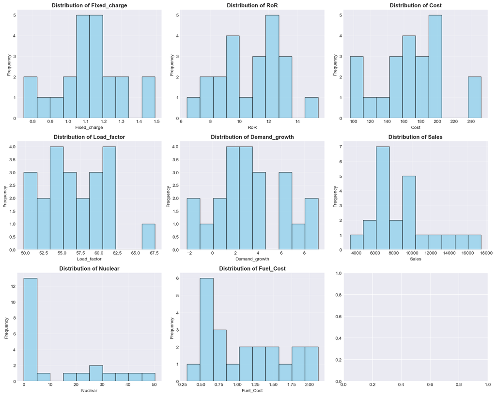

```
💡 Observations:
   - Notice which features have wide ranges
   - Some features vary a lot (like Sales), others less (like Fixed_charge)
   - This is why we'll need to SCALE the data before clustering!
```

```python
# Select numeric columns (exclude Company name)
numeric_cols = df.select_dtypes(include=[np.number]).columns.tolist()

# Create histograms for all numeric features
fig, axes = plt.subplots(3, 3, figsize=(15, 12))
axes = axes.ravel()

for idx, col in enumerate(numeric_cols):
    axes[idx].hist(df[col], bins=10, color='skyblue', edgecolor='black', alpha=0.7)
    axes[idx].set_title(f'Distribution of {col}', fontsize=12, fontweight='bold')
    axes[idx].set_xlabel(col)
    axes[idx].set_ylabel('Frequency')
    axes[idx].grid(True, alpha=0.3)

plt.tight_layout()
plt.show()

print("\n💡 Observations:")
print("   - Notice which features have wide ranges")
print("   - Some features vary a lot (like Sales), others less (like Fixed_charge)")
print("   - This is why we'll need to SCALE the data before clustering!")
```

### Visualize Sales vs Fuel_Cost (Our Main Features)

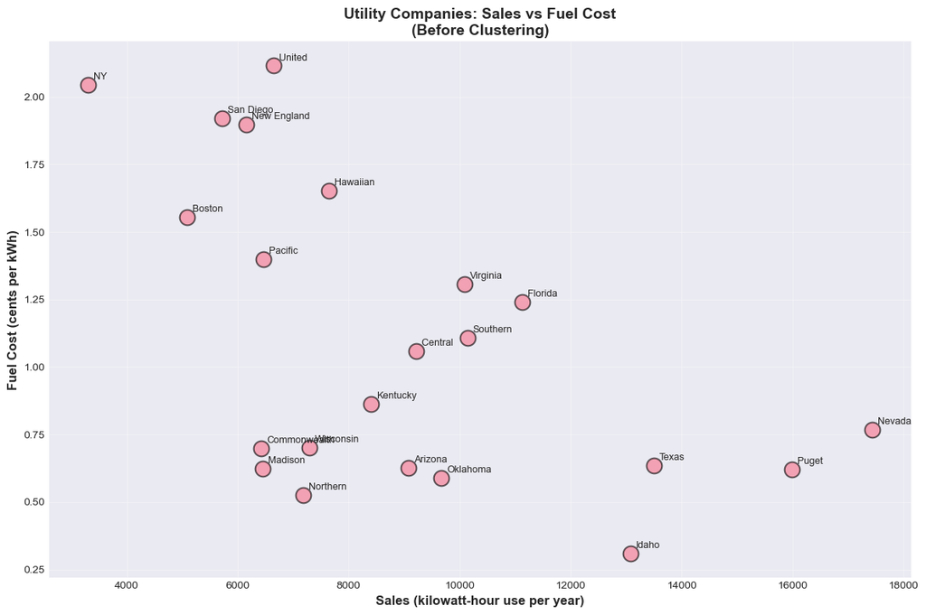

```
 Look at the plot:
   - Can you already see some natural groups?
   - Some companies have high sales, some low
   - Some have high fuel costs, some low
   - Clustering will help us formalize these groups!
```

```python
# Scatter plot: Sales vs Fuel_Cost
plt.figure(figsize=(12, 8))
plt.scatter(df['Sales'], df['Fuel_Cost'], s=200, alpha=0.6, edgecolors='black', linewidth=1.5)

# Add company names as labels
for idx, row in df.iterrows():
    plt.annotate(row['Company'],
                 (row['Sales'], row['Fuel_Cost']),
                 fontsize=9,
                 xytext=(5, 5),
                 textcoords='offset points')

plt.xlabel('Sales (kilowatt-hour use per year)', fontsize=12, fontweight='bold')
plt.ylabel('Fuel Cost (cents per kWh)', fontsize=12, fontweight='bold')
plt.title('Utility Companies: Sales vs Fuel Cost\n(Before Clustering)', fontsize=14, fontweight='bold')
plt.grid(True, alpha=0.3)
plt.tight_layout()
plt.show()

print("\n Look at the plot:")
print("   - Can you already see some natural groups?")
print("   - Some companies have high sales, some low")
print("   - Some have high fuel costs, some low")
print("   - Clustering will help us formalize these groups!")
```

### Correlation Heatmap

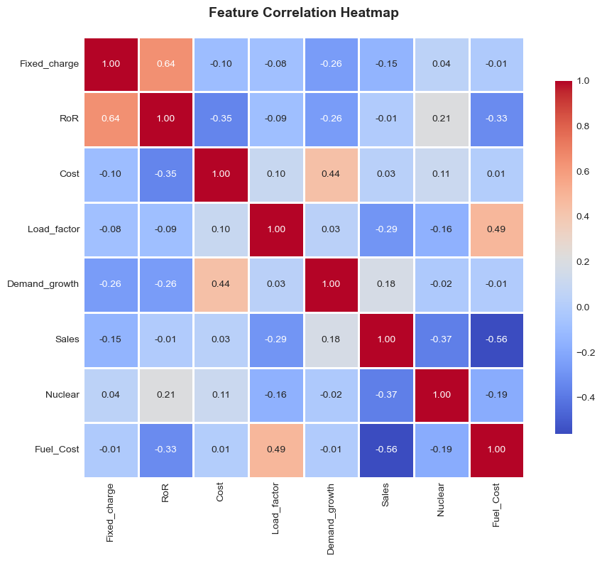

```
💡 Understanding the heatmap:
   - Dark red: Strong positive correlation (features move together)
   - Dark blue: Strong negative correlation (features move opposite)
   - White: No correlation
   - Diagonal is always 1.0 (feature correlates perfectly with itself!)
```

```python
# Calculate correlation matrix
correlation = df[numeric_cols].corr()

# Plot heatmap
plt.figure(figsize=(10, 8))
sns.heatmap(correlation, annot=True, fmt='.2f', cmap='coolwarm',
            square=True, linewidths=1, cbar_kws={"shrink": 0.8})
plt.title('Feature Correlation Heatmap', fontsize=14, fontweight='bold', pad=20)
plt.tight_layout()
plt.show()

print("\n💡 Understanding the heatmap:")
print("   - Dark red: Strong positive correlation (features move together)")
print("   - Dark blue: Strong negative correlation (features move opposite)")
print("   - White: No correlation")
print("   - Diagonal is always 1.0 (feature correlates perfectly with itself!)")
```

## 7. Task 1: K-Means Clustering with 2 Features (Sales & Fuel_Cost) 🎯

Let's start simple! We'll cluster companies using only **Sales** and **Fuel_Cost** so we can visualize the results in 2D.

### Why Start with 2 Features?

- ✅ Easy to visualize (2D scatter plot)
- ✅ Understand how clustering works
- ✅ See the clusters with your own eyes!

### Steps:

1. Prepare the data (select features and scale)
2. Apply K-Means with K=3 clusters
3. Visualize the results

### Step 1: Prepare Data for Clustering

**Important Concept: Feature Scaling** 📏

Before clustering, we must **scale** our features. Why?

- **Sales** ranges from ~3,000 to ~17,000 (large numbers)
- **Fuel_Cost** ranges from ~0.3 to ~2.0 (small numbers)

If we don't scale:

- Distance will be dominated by Sales (because it has bigger numbers)
- Fuel_Cost will barely matter!

**Solution: StandardScaler**

- Transforms each feature to have mean=0 and std=1
- Now all features are on the same scale!
- Fair comparison! ⚖️

```python
### YOUR CODE HERE ###
# Step 1: Select only Sales and Fuel_Cost columns
X = df[['Sales', 'Fuel_Cost']]

# Note there is no output variable y.

# Step 2: Create a StandardScaler object
scaler = StandardScaler()

# Step 3: Fit and transform the data
X_scaled = scaler.fit_transform(X)

# Step 4: Print shapes to verify
print(f"Original data shape: {X.shape}")
print(f"Scaled data shape: {X_scaled.shape}")

### END YOUR CODE ###
```

```
Original data shape: (22, 2)
Scaled data shape: (22, 2)
```

### Step 2: Apply K-Means Clustering (K=3)

We'll create **3 clusters** to start. Later, we'll learn how to choose the best K!

```python
### YOUR CODE HERE ###
# Step 1: Create KMeans object with n_clusters=3
kmeans = KMeans(n_clusters=3, random_state=42, n_init=10)
# random_state=42 ensures reproducible results
# n_init=10 means run algorithm 10 times and pick best result

# Step 2: Fit the model to scaled data
kmeans.fit(X_scaled)

# Step 3: Get cluster labels for each company
labels = kmeans.labels_

# Step 4: Get cluster centers (centroids)
centers = kmeans.cluster_centers_

# Step 5: Add cluster labels to original dataframe
df['Cluster'] = labels

# Step 6: Print summary
print(f"\n✅ K-Means clustering complete!")
print(f"Number of clusters: {kmeans.n_clusters}")
print(f"Inertia (tightness): {kmeans.inertia_:.2f}")


### END YOUR CODE ###
```

```
✅ K-Means clustering complete!
Number of clusters: 3
Inertia (tightness): 8.66
```

### Step 3: Analyze the Clusters

```python
# Show which companies are in which cluster
print("\n🏢 Companies by Cluster:\n")
for cluster_num in range(3):
    print(f"\n{'='*50}")
    print(f"CLUSTER {cluster_num}:")
    print(f"{'='*50}")
    cluster_companies = df[df['Cluster'] == cluster_num]['Company'].tolist()
    for company in cluster_companies:
        print(f"  - {company}")
    print(f"Total: {len(cluster_companies)} companies")
```

```
🏢 Companies by Cluster:


==================================================
CLUSTER 0:
==================================================
  - Arizona
  - Central
  - Commonwealth
  - Florida
  - Kentucky
  - Madison
  - Northern
  - Oklahoma
  - Southern
  - Wisconsin
  - Virginia
Total: 11 companies

==================================================
CLUSTER 1:
==================================================
  - Boston
  - NY
  - Hawaiian
  - New England
  - Pacific
  - San Diego
  - United
Total: 7 companies

==================================================
CLUSTER 2:
==================================================
  - Idaho
  - Nevada
  - Puget
  - Texas
Total: 4 companies
```

```python
# Calculate mean values for each cluster
print("\n📊 Cluster Characteristics (Average Values):\n")
cluster_summary = df.groupby('Cluster')[['Sales', 'Fuel_Cost']].mean().round(2)
cluster_summary
```

```
📊 Cluster Characteristics (Average Values):
```

| Cluster | Sales | Fuel_Cost |
| --- | --- | --- |
| 0 | 8642.91 | 0.85 |
| 1 | 5859.43 | 1.80 |
| 2 | 15005.25 | 0.58 |

### Step 4: Visualize the Clusters! 🎨

This is the fun part - seeing the clusters!

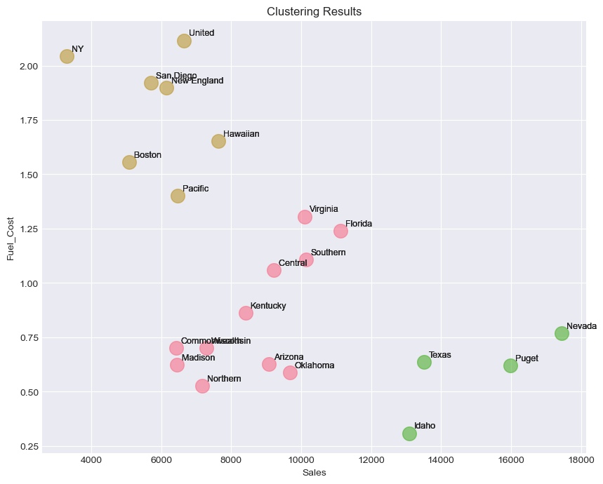

```python
### YOUR CODE HERE ###
# Create a scatter plot with different colors for each cluster
#
# Hints:
# 1. Create figure: plt.figure(figsize=(12, 8))
# 2. Loop through each cluster (0, 1, 2)
# 3. For each cluster, plot points with different color:
#    cluster_data = df[df['Cluster'] == cluster_num]
#    plt.scatter(cluster_data['Sales'], cluster_data['Fuel_Cost'],
#                label=f'Cluster {cluster_num}', s=200, alpha=0.6)
# 4. Add company name labels
# 5. Plot centroids (transform back from scaled space using scaler.inverse_transform())
# 6. Add labels, title, legend
plt.figure(figsize=(10, 8))

for cluster_num in range(3):
    cluster_data = df[df['Cluster'] == cluster_num]
    plt.scatter(cluster_data['Sales'], cluster_data['Fuel_Cost'],
    label=f'Cluster {cluster_num}', s=200, alpha=0.6)

    for idx, row in df.iterrows():
        plt.annotate(row['Company'],
                 (row['Sales'], row['Fuel_Cost']),
                 fontsize=9,
                 xytext=(5, 5),
                 textcoords='offset points')

centroids_original = scaler.inverse_transform(kmeans.cluster_centers_)

plt.xlabel("Sales")
plt.ylabel("Fuel_Cost")
plt.title("Clustering Results")

### END YOUR CODE ###
```

### Questions to Think About 🤔

Look at your visualization:

1. Do the clusters make sense?
2. What characterizes each cluster?
   - Cluster 0: High/Low sales? High/Low fuel cost?
   - Cluster 1: High/Low sales? High/Low fuel cost?
   - Cluster 2: High/Low sales? High/Low fuel cost?
3. Are there any companies that seem "on the border" between clusters?

## 8. Task 2: Choosing K with the Elbow Method 📐

### The Big Question: How Many Clusters?

So far, we used K=3, but **how do we know 3 is the right number?**

Maybe 2 clusters is better? Or 4? Or 5?

### The Elbow Method 💪

The **Elbow Method** helps us choose K!

**How it works:**

1. Try different values of K (e.g., K=1, 2, 3, 4, 5, 6, 7, 8)
2. For each K, measure the **inertia** (how tight the clusters are)
3. Plot K vs Inertia
4. Look for the "elbow" (bend in the curve)

### Understanding Inertia 📏

**Inertia** = Sum of squared distances from each point to its cluster center

- **Lower inertia** = Points are close to their centroids = Tight clusters = Good! ✅
- **Higher inertia** = Points are far from centroids = Loose clusters = Not great ❌

**Important Pattern:**

- More clusters → Lower inertia (always!)
- K=1 → Very high inertia (everything in one big loose group)
- K=N (each point its own cluster) → Inertia = 0 (perfect but useless!)

### Why "Elbow"? 🤷

When you plot K vs Inertia, it looks like an arm:

```
Inertia
  |
  |●
  | \
  |  \
  |   ●
  |    \
  |     ●___●___●___●  ← After the elbow, improvement is small
  |      ↑ ELBOW!
  |_________________ K
```

**The "elbow"** is where:

- Adding more clusters stops helping much
- The curve bends (like an elbow)
- **That K value is usually best!**

### Example Interpretation:

- K=1 → Inertia = 1000 (too loose!)
- K=2 → Inertia = 500 (big improvement! ⬇️)
- K=3 → Inertia = 250 (big improvement! ⬇️) **← ELBOW!**
- K=4 → Inertia = 200 (small improvement)
- K=5 → Inertia = 195 (tiny improvement)
- K=6 → Inertia = 190 (tiny improvement)

**Conclusion:** K=3 is probably best! After that, we're not getting much benefit.

Let's find the elbow for our data!

### Calculate Inertia for Different K Values

```python
### YOUR CODE HERE ###
# Step 1: Create a list to store inertia values
inertias = []

# Step 2: Try K from 1 to 8
k_range = range(1, 9)

# Step 3: For each K:
#    - Create KMeans model with that K
#    - Fit to data
#    - Store the inertia
# Hint:
for k in k_range:
    kmeans = KMeans(n_clusters=k, random_state=42, n_init=10)
    kmeans.fit(X_scaled)
    inertias.append(kmeans.inertia_)

# Step 4: Print the results
print("\n📊 Inertia for different K values:\n")
for k, inertia in zip(k_range, inertias):
    print(f"K={k}: Inertia={inertia:.2f}")



### END YOUR CODE ###
```

```
📊 Inertia for different K values:

K=1: Inertia=44.00
K=2: Inertia=19.24
K=3: Inertia=8.66
K=4: Inertia=5.18
K=5: Inertia=3.84
K=6: Inertia=2.70
K=7: Inertia=1.98
K=8: Inertia=1.45
```

### Plot the Elbow Curve

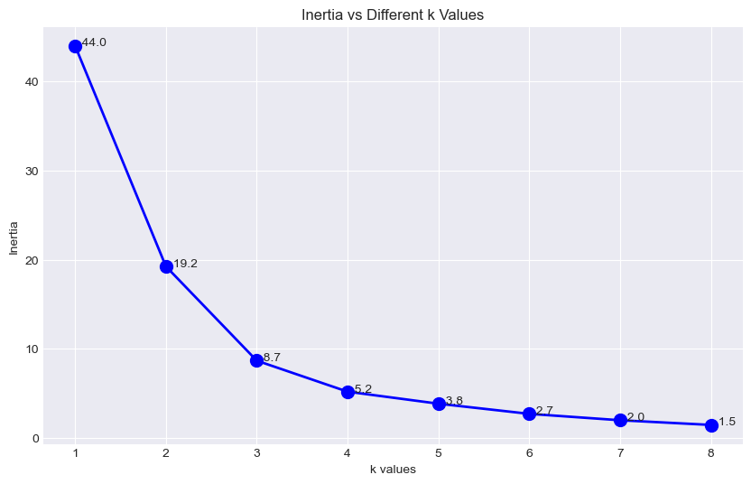

```python
### YOUR CODE HERE ###
# Create elbow plot
#
# Hints:
# 1. plt.figure(figsize=(10, 6))
# 2. plt.plot(k_range, inertias, 'bo-', linewidth=2, markersize=10)
# 3. Add labels and title
# 4. Add grid
# 5. Mark each point with K value
#    for k, inertia in zip(k_range, inertias):
#        plt.text(k, inertia, f'  {inertia:.1f}', fontsize=10)
plt.figure(figsize=(10, 6))
plt.plot(k_range, inertias, 'bo-', linewidth=2, markersize=10)

plt.xlabel("k values")
plt.ylabel("Inertia")
plt.title("Inertia vs Different k Values")
plt.grid(True)

for k, inertia in zip(k_range, inertias):
   plt.text(k, inertia, f'  {inertia:.1f}', fontsize=10)

### END YOUR CODE ###
```

### Interpretation Questions 🤔

Look at your elbow plot:

1. Where is the "elbow" (the bend in the curve)?
2. What K value does the elbow suggest?
3. After the elbow, how much does inertia decrease with each additional cluster?
4. Does K=3 (what we used before) seem like a good choice?

**Write your observations:**

Now let's use **ALL features** for clustering, not just Sales and Fuel_Cost!

### Why Use All Features?

Using only 2 features is like:

- Judging a car only by color and price ❌

Using all features is like:

- Judging a car by color, price, speed, fuel efficiency, safety, etc. ✅

**More information = Better clusters!**

### Challenge:

- Use all features for clustering
- Still visualize using Sales vs Fuel_Cost (2D projection)
- Analyze cluster characteristics across all features

### Step 1: Prepare All Features

```python
### YOUR CODE HERE ###
# Step 1: Select all numeric features (exclude Company name)
feature_columns = ['Fixed_charge', 'RoR', 'Cost', 'Load_factor',
                          'Demand_growth', 'Sales', 'Nuclear', 'Fuel_Cost']
X_all = df[feature_columns]

# Step 2: Scale the features
scaler_all = StandardScaler()
X_all_scaled = scaler_all.fit_transform(X_all)

# Step 3: Print shape
print(f"All features data shape: {X_all_scaled.shape}")
print(f"Using {X_all_scaled.shape[1]} features for clustering")



### END YOUR CODE ###
```

```
All features data shape: (22, 8)
Using 8 features for clustering
```

### Step 2: Find Optimal K with Elbow Method

```
📊 Inertia for different K values:

K=1: Inertia=176.00
K=2: Inertia=137.45
K=3: Inertia=106.55
K=4: Inertia=85.28
K=5: Inertia=71.11
K=6: Inertia=61.01
K=7: Inertia=53.74
K=8: Inertia=47.41
```

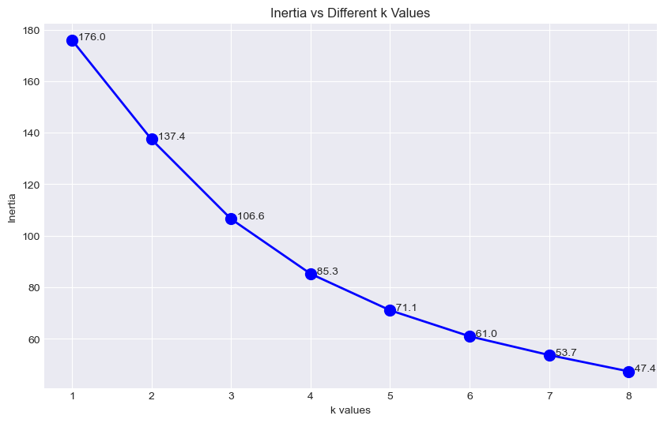

```python
### YOUR CODE HERE ###
# Calculate inertia for K=1 to K=8 using ALL features
# Then plot the elbow curve
# (Same as Task 2, but with X_all_scaled instead of X_scaled)
inertias = []

k_range = range(1, 9)

for k in k_range:
    kmeans = KMeans(n_clusters=k, random_state=42, n_init=10)
    kmeans.fit(X_all_scaled)
    inertias.append(kmeans.inertia_)

print("\n📊 Inertia for different K values:\n")
for k, inertia in zip(k_range, inertias):
    print(f"K={k}: Inertia={inertia:.2f}")

plt.figure(figsize=(10, 6))
plt.plot(k_range, inertias, 'bo-', linewidth=2, markersize=10)

plt.xlabel("k values")
plt.ylabel("Inertia")
plt.title("Inertia vs Different k Values")
plt.grid(True)

for k, inertia in zip(k_range, inertias):
   plt.text(k, inertia, f'  {inertia:.1f}', fontsize=10)

### END YOUR CODE ###
```

### Step 3: Apply K-Means with Chosen K

```python
### YOUR CODE HERE ###
# Based on elbow plot, choose K (let's say K=3 for now, adjust based on your plot)
#
# Step 1: Create and fit KMeans
# Step 2: Get labels and add to dataframe as 'Cluster_All'
# Step 3: Print results
kmeans_all = KMeans(n_clusters=2, random_state=42, n_init=10)

kmeans_all.fit(X_scaled)

labels = kmeans_all.labels_

centers = kmeans_all.cluster_centers_

df['Cluster_All'] = labels

print("\n Clustering completed.")

### END YOUR CODE ###
```

```
 Clustering completed.
```

```python
# Show cluster characteristics
print("\n📊 Cluster Characteristics (All Features):\n")
cluster_summary_all = df.groupby('Cluster_All')[feature_columns].mean().round(2)
cluster_summary_all
```

```
📊 Cluster Characteristics (All Features):
```

| Cluster_All | Fixed_charge | RoR | Cost | Load_factor | Demand_growth | Sales | Nuclear | Fuel_Cost |
| --- | --- | --- | --- | --- | --- | --- | --- | --- |
| 0 | 1.13 | 11.43 | 163.27 | 55.31 | 3.32 | 10339.53 | 14.26 | 0.78 |
| 1 | 1.07 | 9.26 | 178.71 | 60.54 | 3.07 | 5859.43 | 7.16 | 1.80 |

```python
# Show companies in each cluster
print("\n🏢 Companies by Cluster (Using All Features):\n")
for cluster_num in sorted(df['Cluster_All'].unique()):
    print(f"\n{'='*50}")
    print(f"CLUSTER {cluster_num}:")
    print(f"{'='*50}")
    cluster_companies = df[df['Cluster_All'] == cluster_num]['Company'].tolist()
    for company in cluster_companies:
        print(f"  - {company}")
    print(f"Total: {len(cluster_companies)} companies")
```

```
🏢 Companies by Cluster (Using All Features):


==================================================
CLUSTER 0:
==================================================
  - Arizona
  - Central
  - Commonwealth
  - Florida
  - Idaho
  - Kentucky
  - Madison
  - Nevada
  - Northern
  - Oklahoma
  - Puget
  - Southern
  - Texas
  - Wisconsin
  - Virginia
Total: 15 companies

==================================================
CLUSTER 1:
==================================================
  - Boston
  - NY
  - Hawaiian
  - New England
  - Pacific
  - San Diego
  - United
Total: 7 companies
```

### Step 5: Visualize (Using Sales vs Fuel_Cost Projection)

[figure not shown]

```python
### YOUR CODE HERE ###
# Create scatter plot similar to Task 1
# But use Cluster_All for colors (not Cluster)
# This shows how clusters based on ALL features project onto 2D space

plt.figure(figsize=(10, 8))

for cluster_num in range(3):
    cluster_data = df[df['Cluster_All'] == cluster_num]
    plt.scatter(cluster_data['Sales'], cluster_data['Fuel_Cost'],
    label=f'Cluster {cluster_num}', s=200, alpha=0.6)

    for idx, row in df.iterrows():
        plt.annotate(row['Company'],
                 (row['Sales'], row['Fuel_Cost']),
                 fontsize=9,
                 xytext=(5, 5),
                 textcoords='offset points')

plt.xlabel("Sales")
plt.ylabel("Fuel_Cost")
plt.title("Clustering Results")


### END YOUR CODE ###
```

### Comparison: 2-Features vs All-Features 🤔

Compare the results:

1. Are the clusters different when using all features vs just 2?
2. Which companies changed clusters?
3. Do the all-features clusters make more sense?
4. Look at the cluster characteristics table - what makes each cluster unique?

**Write your observations:**

## 10. Task 4: Hierarchical Clustering with 2 Features 🌳

Now let's try a different clustering method: **Hierarchical Clustering**!

Remember:

- K-Means = Fixed number of clusters from the start
- Hierarchical = Build a tree, cut it wherever you want!

### Step 1: Create the Dendrogram 🌳

The dendrogram shows how clusters merge!

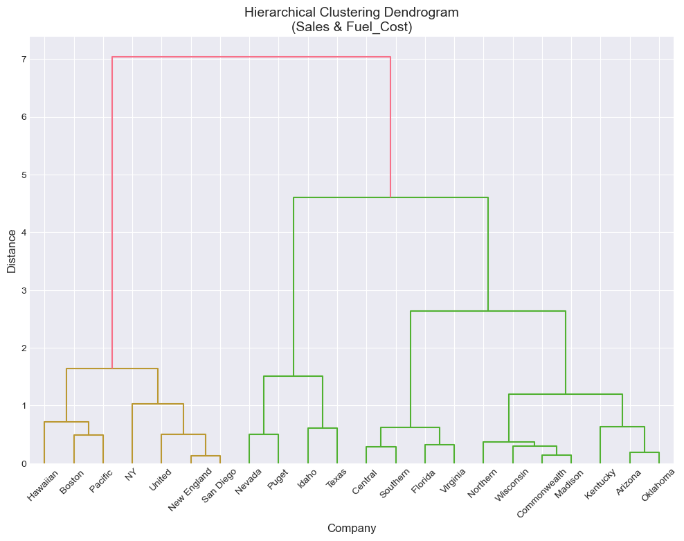

```python
### YOUR CODE HERE ###
# Step 1: Calculate linkage matrix using Ward's method
linkage_matrix = linkage(X_scaled, method='ward')
# Ward's method minimizes variance within clusters

# Step 2: Create dendrogram
# Hints:
plt.figure(figsize=(12, 8))
dendrogram(linkage_matrix, labels=df['Company'].values,
           leaf_font_size=10, leaf_rotation=45)
plt.title('Hierarchical Clustering Dendrogram\n(Sales & Fuel_Cost)', fontsize=14)
plt.xlabel('Company', fontsize=12)
plt.ylabel('Distance', fontsize=12)



### END YOUR CODE ###
```

### Understanding the Dendrogram 📖

**How to read it:**

1. **Bottom (leaves):** Each company starts as its own cluster
2. **Vertical lines:** Show when clusters merge
3. **Height of merge:** How different the clusters are
   - Short height = very similar clusters merging
   - Tall height = very different clusters merging
4. **Horizontal cut:** Choose how many clusters
   - Cut high → Few clusters (2-3)
   - Cut low → Many clusters (5-6)

**Example:**

```
Height
  20 |              __________________
     |             |                  |
  15 |        _____|_____        _____|_____
     |       |           |      |           |
  10 |    ___|___     ___|___   |      _____|_____
     |   |       |   |       |  |     |           |
   5 | __|__   __|__ |    ___|__|   __|__      ___|___
     | |    | |    | |   |      |  |     |    |       |
   0  A B  C D  E F G  H I    J K  L M  N O  P Q    R S

Cut at height 15: → 3 clusters
Cut at height 10: → 5 clusters
```

### Step 2: Apply Agglomerative Clustering with K=3

```python
### YOUR CODE HERE ###
# Step 1: Create AgglomerativeClustering model
hier_clust = AgglomerativeClustering(n_clusters=3, linkage='ward')

# Step 2: Fit and predict
hier_labels = hier_clust.fit_predict(X_scaled)

# Step 3: Add labels to dataframe
df['Cluster_Hier'] = hier_labels

# Step 4: Print results
print(f"\n✅ Hierarchical clustering complete!")
print(f"Number of clusters: {hier_clust.n_clusters}")



### END YOUR CODE ###
```

```
✅ Hierarchical clustering complete!
Number of clusters: 3
```

### Step 3: Visualize Hierarchical Clusters

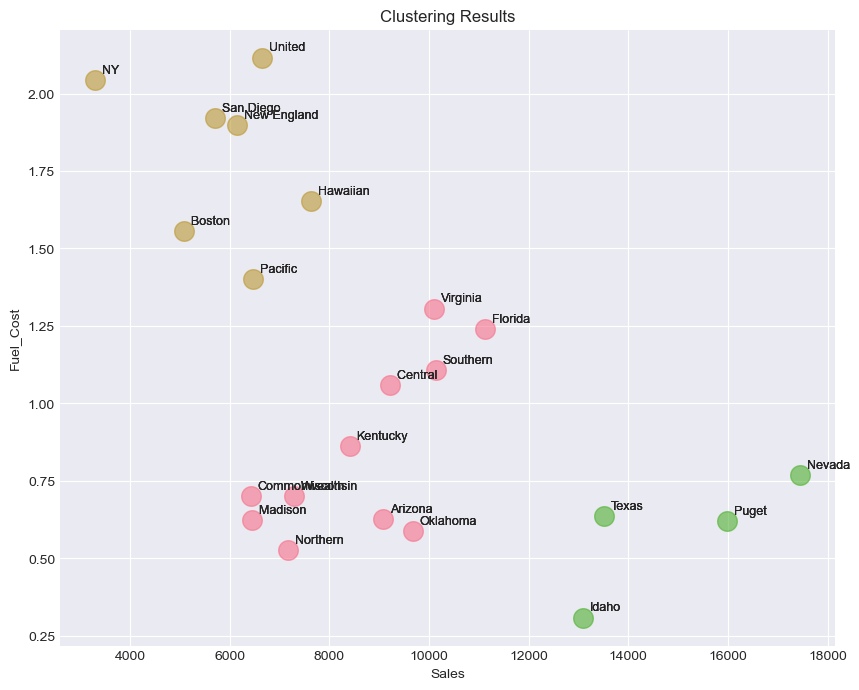

```python
### YOUR CODE HERE ###
# Create scatter plot with Hierarchical cluster colors
# Similar to previous visualizations
plt.figure(figsize=(10, 8))

for cluster_num in range(3):
    cluster_data = df[df['Cluster_Hier'] == cluster_num]
    plt.scatter(cluster_data['Sales'], cluster_data['Fuel_Cost'],
    label=f'Cluster {cluster_num}', s=200, alpha=0.6)

    for idx, row in df.iterrows():
        plt.annotate(row['Company'],
                 (row['Sales'], row['Fuel_Cost']),
                 fontsize=9,
                 xytext=(5, 5),
                 textcoords='offset points')

plt.xlabel("Sales")
plt.ylabel("Fuel_Cost")
plt.title("Clustering Results")


### END YOUR CODE ###
```

### Step 4: Compare K-Means vs Hierarchical

```python
# Compare cluster assignments
comparison = df[['Company', 'Cluster', 'Cluster_Hier', 'Sales', 'Fuel_Cost']].sort_values('Company')
print("\n🔍 K-Means vs Hierarchical Clustering Comparison:\n")
comparison
```

```
🔍 K-Means vs Hierarchical Clustering Comparison:
```

|  | Company | Cluster | Cluster_Hier | Sales | Fuel_Cost |
| --- | --- | --- | --- | --- | --- |
| 0 | Arizona | 0 | 0 | 9077 | 0.628 |
| 1 | Boston | 1 | 1 | 5088 | 1.555 |
| 2 | Central | 0 | 0 | 9212 | 1.058 |
| 3 | Commonwealth | 0 | 0 | 6423 | 0.700 |
| 5 | Florida | 0 | 0 | 11127 | 1.241 |
| 6 | Hawaiian | 1 | 1 | 7642 | 1.652 |
| 7 | Idaho | 2 | 2 | 13082 | 0.309 |
| 8 | Kentucky | 0 | 0 | 8406 | 0.862 |
| 9 | Madison | 0 | 0 | 6455 | 0.623 |
| 4 | NY | 1 | 1 | 3300 | 2.044 |
| 10 | Nevada | 2 | 2 | 17441 | 0.768 |
| 11 | New England | 1 | 1 | 6154 | 1.897 |
| 12 | Northern | 0 | 0 | 7179 | 0.527 |
| 13 | Oklahoma | 0 | 0 | 9673 | 0.588 |
| 14 | Pacific | 1 | 1 | 6468 | 1.400 |
| 15 | Puget | 2 | 2 | 15991 | 0.620 |
| 16 | San Diego | 1 | 1 | 5714 | 1.920 |
| 17 | Southern | 0 | 0 | 10140 | 1.108 |
| 18 | Texas | 2 | 2 | 13507 | 0.636 |
| 20 | United | 1 | 1 | 6650 | 2.116 |
| 21 | Virginia | 0 | 0 | 10093 | 1.306 |
| 19 | Wisconsin | 0 | 0 | 7287 | 0.702 |

```python
# Count how many companies have same cluster in both methods
# Note: Cluster numbers might be different (0,1,2 vs 1,2,0) but represent same groups
print("\n📊 Cluster Assignment Comparison:")
print(f"Total companies: {len(df)}")
print(f"Companies with same cluster number: {(df['Cluster'] == df['Cluster_Hier']).sum()}")
print("\n⚠️ Note: Even if numbers are different, clusters might represent same groups!")
```

```
📊 Cluster Assignment Comparison:
Total companies: 22
Companies with same cluster number: 22

⚠️ Note: Even if numbers are different, clusters might represent same groups!
```

## 11. Task 5: Hierarchical Clustering with All Features 🌳

Finally, let's apply Hierarchical Clustering using all features!

### Step 1: Create Dendrogram with All Features

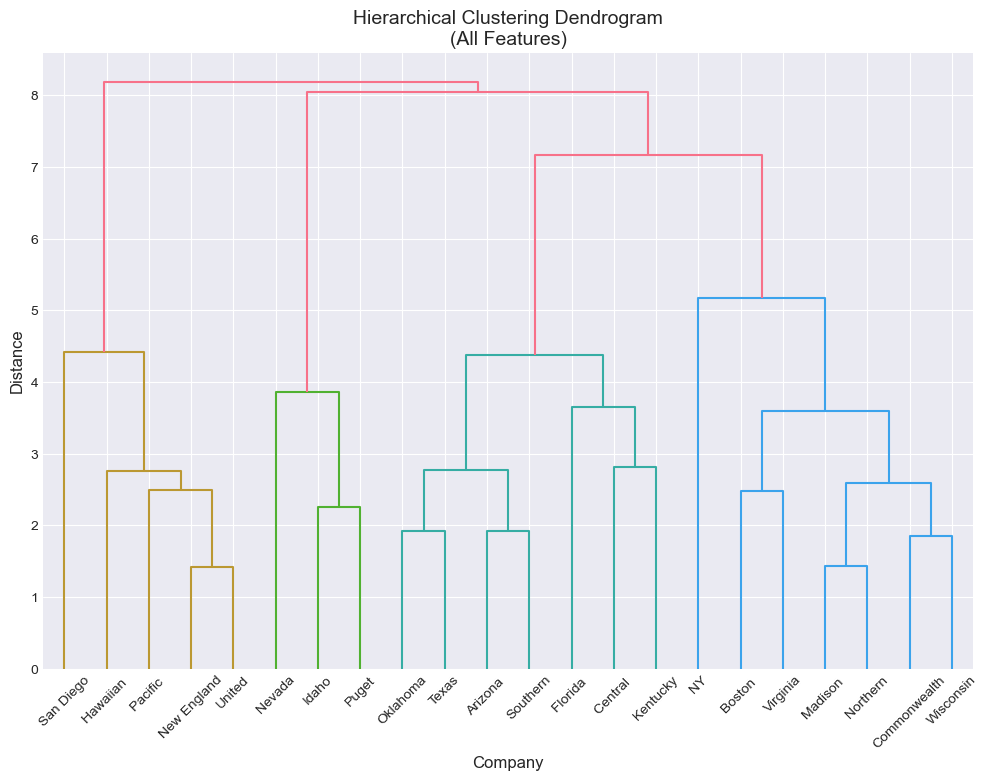

```python
### YOUR CODE HERE ###
# Create dendrogram using X_all_scaled (all features)
# Same as Task 4, but with all features
linkage_matrix = linkage(X_all_scaled, method='ward')

plt.figure(figsize=(12, 8))
dendrogram(linkage_matrix, labels=df['Company'].values,
           leaf_font_size=10, leaf_rotation=45)
plt.title('Hierarchical Clustering Dendrogram\n(All Features)', fontsize=14)
plt.xlabel('Company', fontsize=12)
plt.ylabel('Distance', fontsize=12)


### END YOUR CODE ###
```

### Step 2: Choose K Based on Dendrogram

Look at your dendrogram:

- Where would you make a horizontal cut?
- How many clusters does it suggest?
- Are there clear gaps in the tree?

```python
### YOUR CODE HERE ###
# Based on dendrogram, choose K and apply AgglomerativeClustering
# Add results to dataframe as 'Cluster_Hier_All'
hier_clust = AgglomerativeClustering(n_clusters=7, linkage='ward')

# Step 2: Fit and predict
hier_labels = hier_clust.fit_predict(X_all_scaled)

# Step 3: Add labels to dataframe
df['Cluster_Hier_All'] = hier_labels

# Step 4: Print results
print(f"\n✅ Hierarchical clustering complete!")
print(f"Number of clusters: {hier_clust.n_clusters}")


### END YOUR CODE ###
```

```
✅ Hierarchical clustering complete!
Number of clusters: 7
```

### Step 3: Analyze Final Clusters

```python
# Cluster characteristics
print("\n📊 Hierarchical Cluster Characteristics (All Features):\n")
cluster_summary_hier = df.groupby('Cluster_Hier_All')[feature_columns].mean().round(2)
cluster_summary_hier
```

```
📊 Hierarchical Cluster Characteristics (All Features):
```

| Cluster_Hier_All | Fixed_charge | RoR | Cost | Load_factor | Demand_growth | Sales | Nuclear | Fuel_Cost |
| --- | --- | --- | --- | --- | --- | --- | --- | --- |
| 0 | 1.00 | 8.87 | 223.33 | 54.83 | 6.33 | 15504.67 | 0.00 | 0.57 |
| 1 | 1.08 | 11.28 | 181.33 | 55.80 | 3.50 | 7087.50 | 36.12 | 0.90 |
| 2 | 1.36 | 13.97 | 130.67 | 57.80 | 2.80 | 9581.67 | 7.50 | 1.05 |
| 3 | 1.09 | 9.82 | 180.25 | 63.20 | 2.33 | 6728.50 | 0.22 | 1.77 |
| 4 | 1.49 | 8.80 | 192.00 | 51.20 | 1.00 | 3300.00 | 15.60 | 2.04 |
| 5 | 0.76 | 6.40 | 136.00 | 61.90 | 9.00 | 5714.00 | 8.30 | 1.92 |
| 6 | 1.09 | 11.38 | 125.25 | 53.72 | 0.90 | 10599.25 | 0.00 | 0.74 |

```python
# Companies in each cluster
print("\n🏢 Final Hierarchical Clusters:\n")
for cluster_num in sorted(df['Cluster_Hier_All'].unique()):
    print(f"\n{'='*50}")
    print(f"CLUSTER {cluster_num}:")
    print(f"{'='*50}")
    cluster_companies = df[df['Cluster_Hier_All'] == cluster_num]['Company'].tolist()
    for company in cluster_companies:
        print(f"  - {company}")
    print(f"Total: {len(cluster_companies)} companies")
```

```
🏢 Final Hierarchical Clusters:


==================================================
CLUSTER 0:
==================================================
  - Idaho
  - Nevada
  - Puget
Total: 3 companies

==================================================
CLUSTER 1:
==================================================
  - Boston
  - Commonwealth
  - Madison
  - Northern
  - Wisconsin
  - Virginia
Total: 6 companies

==================================================
CLUSTER 2:
==================================================
  - Central
  - Florida
  - Kentucky
Total: 3 companies

==================================================
CLUSTER 3:
==================================================
  - Hawaiian
  - New England
  - Pacific
  - United
Total: 4 companies

==================================================
CLUSTER 4:
==================================================
  - NY
Total: 1 companies

==================================================
CLUSTER 5:
==================================================
  - San Diego
Total: 1 companies

==================================================
CLUSTER 6:
==================================================
  - Arizona
  - Oklahoma
  - Southern
  - Texas
Total: 4 companies
```

### Step 4: Final Comparison - All Methods

```python
# Create comprehensive comparison table
final_comparison = df[['Company', 'Cluster', 'Cluster_All', 'Cluster_Hier', 'Cluster_Hier_All']].sort_values('Company')
final_comparison.columns = ['Company', 'KMeans_2F', 'KMeans_AllF', 'Hier_2F', 'Hier_AllF']

print("\n🎯 FINAL COMPARISON: All Clustering Methods\n")
print("Legend:")
print("  KMeans_2F = K-Means with 2 features (Sales, Fuel_Cost)")
print("  KMeans_AllF = K-Means with all features")
print("  Hier_2F = Hierarchical with 2 features")
print("  Hier_AllF = Hierarchical with all features")
print("\n")
final_comparison
```

```
🎯 FINAL COMPARISON: All Clustering Methods

Legend:
  KMeans_2F = K-Means with 2 features (Sales, Fuel_Cost)
  KMeans_AllF = K-Means with all features
  Hier_2F = Hierarchical with 2 features
  Hier_AllF = Hierarchical with all features
```

|  | Company | KMeans_2F | KMeans_AllF | Hier_2F | Hier_AllF |
| --- | --- | --- | --- | --- | --- |
| 0 | Arizona | 0 | 0 | 0 | 6 |
| 1 | Boston | 1 | 1 | 1 | 1 |
| 2 | Central | 0 | 0 | 0 | 2 |
| 3 | Commonwealth | 0 | 0 | 0 | 1 |
| 5 | Florida | 0 | 0 | 0 | 2 |
| 6 | Hawaiian | 1 | 1 | 1 | 3 |
| 7 | Idaho | 2 | 0 | 2 | 0 |
| 8 | Kentucky | 0 | 0 | 0 | 2 |
| 9 | Madison | 0 | 0 | 0 | 1 |
| 4 | NY | 1 | 1 | 1 | 4 |
| 10 | Nevada | 2 | 0 | 2 | 0 |
| 11 | New England | 1 | 1 | 1 | 3 |
| 12 | Northern | 0 | 0 | 0 | 1 |
| 13 | Oklahoma | 0 | 0 | 0 | 6 |
| 14 | Pacific | 1 | 1 | 1 | 3 |
| 15 | Puget | 2 | 0 | 2 | 0 |
| 16 | San Diego | 1 | 1 | 1 | 5 |
| 17 | Southern | 0 | 0 | 0 | 6 |
| 18 | Texas | 2 | 0 | 2 | 6 |
| 20 | United | 1 | 1 | 1 | 3 |
| 21 | Virginia | 0 | 0 | 0 | 1 |
| 19 | Wisconsin | 0 | 0 | 0 | 1 |

## 12. Discussion Questions 💭

Answer these questions based on your results. Think deeply!

### Question 1: Elbow Method

**a)** What K value did the elbow method suggest for:

- 2-feature clustering?
- All-feature clustering?

**b)** Were they the same or different? Why do you think that is?

**c)** Is the "elbow" always obvious? What would you do if the curve doesn't have a clear bend?

**Your Answer:**

**a)** 3 and 2.  
**b)** Different.  
**c)** No. Change the distance measuring method.

### Question 2: Feature Selection Impact

**a)** Compare K-Means with 2 features vs all features:

- Did any companies switch clusters?
- Which clustering makes more sense and why?

**b)** Why is it important to use all relevant features for clustering?

**c)** Can using too many features be a problem? (Think about noise/irrelevant features)

**Your Answer:**

### Question 3: Interpreting Clusters

**a)** Look at your final clusters (using all features). Give each cluster a meaningful name based on its characteristics.

Example:

- Cluster 0: "Large, Efficient Companies" (high sales, low fuel cost)
- Cluster 1: "Small, Expensive Companies" (low sales, high fuel cost)
- Cluster 2: "...?"

**b)** If you were a business analyst, how would you use these clusters?

- What insights do they provide?
- What recommendations would you make?

**Your Answer:**

### Question 5: Dendrogram Interpretation

**a)** Look at your dendrogram (all features). Describe what you see:

- Which companies merged first (are most similar)?
- Which merged last (are most different)?

**b)** The dendrogram provides a "history" of clustering. Why is this useful compared to K-Means which just gives final clusters?

**Your Answer:**

a) The companies which is near to each other. b) We can check the process of algorithm. It helps us when we want to find more information bewteen different classes.

## Congratulations! 🎉

You've completed your first unsupervised learning lab!

### What You Learned Today:

✅ **Unsupervised Learning** - Finding patterns without labels  
✅ **Clustering** - Grouping similar items together  
✅ **K-Means Algorithm** - Fast, simple clustering  
✅ **Elbow Method** - Choosing optimal K  
✅ **Hierarchical Clustering** - Building cluster trees  
✅ **Dendrograms** - Visualizing hierarchical relationships  
✅ **Feature Scaling** - Why it's crucial for distance-based methods  
✅ **Cluster Analysis** - Interpreting and understanding results

### Key Takeaways:

1. **Unsupervised ≠ Unsupervised**
   - Just because we don't have labels doesn't mean we can't discover meaningful patterns!
2. **Different Methods, Different Insights**
   - K-Means: Fast, works great for large data, need to choose K
   - Hierarchical: Shows relationships, flexible K, slower
3. **Features Matter!**
   - More relevant features → Better clusters
   - Always scale your features!
4. **Interpretation is Key**
   - Clustering is just the start
   - Understanding WHAT the clusters mean is the real goal!

### Next Steps:

- Attend the theory lecture to deepen your understanding
- Try clustering on your own datasets
- Explore other clustering algorithms (DBSCAN, Gaussian Mixture Models)
- Think about how clustering could solve real problems!

**Great job! See you in the next lab! 🚀**